[figure not shown]

```python
from IPython.display import Image
Image('Supervised-and-Unsupervised-Learning.png')
```

# *Unsupervised Learning*

## What is `unsupervised methods`........?

- Unsupervised learning is where you only have `input data (X)` and `no corresponding output variables`.
- The goal for unsupervised learning is to model the underlying structure or distribution in the data in order to learn more about the data.
- These are called unsupervised learning because unlike supervised learning above there is `no correct answers` and there is no teacher.
- Algorithms are left to their own devises to discover and present the interesting structure in the data.
- In other words, the machine is expected to find the hidden patterns and structure in unlabeled data by their own.
- That’s why it is called unsupervised – there is no supervisor to teach the machine what is right and what is wrong.
- Unsupervised learning is a type of machine learning algorithm `used to draw inferences` from datasets consisting of input data `without labeled responses`.
- The most common unsupervised learning method is `cluster analysis`, which is used for exploratory data analysis to `find hidden patterns or grouping in data`.
- The clusters are modeled using a measure of similarity which is defined upon metrics such as Euclidean or probabilistic distance.
- Unsupervised learning problems can be further grouped into clustering and association problems.
  - **Clustering**:
    - A clustering problem is where you want to discover the inherent groupings in the data, such as grouping customers by purchasing behavior.
    - Clustering is the assignment of a set of objects into subsets (also called clusters) so that objects in the same cluster have similar characteristics in some sense.
    - The goal of clustering is to segregate groups with similar characteristics and then assign them into clusters.
    - A good example here is when you want to group customers by their purchasing behavior.
  - **Association**:
    - An association rule learning problem is where you want to discover rules that describe large portions of your data, such as people that buy X also tend to buy Y.
    - We have association rules that aim to find associations amongst data objects within large databases.
    - Association is about discovering some interesting relationships between variables in large databases.
    - For example, people that buy a new house also tend to buy new furniture.
- So, Clustering is about grouping data points according to their similarities while Association is about discovering some relationships between the attributes of those data points.
- Some popular examples of unsupervised learning algorithms are:
  - `k-means` for clustering problems.
  - `Apriori algorithm` for association rule learning problems.

## How is it different from supervised methods?

- Compared to supervised learning where training data is labeled with the appropriate classifications, models using unsupervised learning must learn relationships between elements in a data set and classify the raw data without "help."
- This hunt for relationships can take many different algorithmic forms, but all models have the same goal of mimicking human logic by searching for indirect hidden structures, patterns or features to analyze new data

## Clustering

- Cluster analysis or clustering is the task of grouping a set of objects in such a way that objects in the same group (called a cluster) are more similar (in some sense) to each other than to those in other groups (clusters).
- Clustering can be considered the most important unsupervised learning problem; so, as every other problem of this kind, it deals with finding a structure in a collection of unlabeled data.
- A loose definition of clustering could be “the process of organizing objects into groups whose members are similar in some way”.
- A cluster is therefore a collection of objects which are “similar” between them and are “dissimilar” to the objects belonging to other clusters.

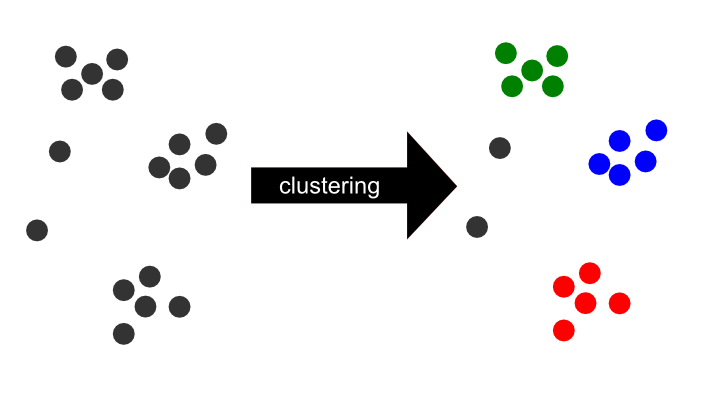

```python
from IPython.display import Image
Image('data-mining-clusteranalyse.png')
```

## The Goals of Clustering

- The goal of clustering is to determine the intrinsic grouping in a set of unlabeled data.
- **How to decide what constitutes a good clustering?**
  - It can be shown that there is no absolute “best” criterion which would be independent of the final aim of the clustering.
  - Consequently, it is the user which must supply this criterion, in such a way that the result of the clustering will suit their needs.
  - For instance, we could be interested in finding representatives for homogeneous groups (data reduction), in finding “natural clusters”
  - and describe their unknown properties (“natural” data types), in finding useful and suitable groupings (“useful” data classes) or in finding unusual data objects (outlier detection).

## Clustering can be broadly classified into flat clustering and hierarchical clustering.

### Flat clustering

- Clustering algorithms group a set of documents into subsets or clusters .
- The algorithms' goal is to create clusters that are coherent internally, but clearly different from each other.
- In other words, documents within a cluster should be as similar as possible; and documents in one cluster should be as dissimilar as possible from documents in other clusters.
- Clustering is the most common form of unsupervised learning .
- No supervision means that there is no human expert who has assigned documents to classes.
- In clustering, it is the distribution and makeup of the data that will determine cluster membership.
- The key input to a clustering algorithm is the distance measure.
- Flat clustering, also called as `partitioning clustering`, *creates flat set of clusters without any explicit structure that would relate clusters to each other.*
- Flat clustering methods are conceptually simple, but they have a number of drawbacks.
- Most of the clustering algorithms, like k-means, require a pre-specified number of clusters as input and are nondeterministic.
- Flat clustering may be viewed as an `optimization problem`.
- An instance is a particular clustering setting:
  - a set of objects,
  - a representation with a similarity measure,
  - and a number of clusters.
  - An assignment is a clustering in this setting.
- The objective/criterion function returns a value for all clusters and the `goal is to find a clustering scenario with an optimal value.`
- In most cases, to find such a clustering would require an exhaustive search, and most partitioning clustering algorithms are local search strategies that are only guaranteed to find a local optimum

## Hierarchical clustering

- Hierarchical clustering builds a cluster hierarchy, or in other words, a tree of clusters.
- Hierarchical clustering output is structured and more informative than flat clustering.
- Hierarchical clustering algorithms are further subdivided into two types:
  - a. `agglomerative methods` - a bottom-up cluster hierarchy generation by fusing objects into groups and groups into higher clusters.
  - b. `divisive methods` - a top-down cluster hierarchy generation by partitioning a single cluster encompassing all objects successively into finer clusters.
- Agglomerative techniques are more commonly used.
- Hierarchical clustering does not require knowing the pre-specified number of clusters.
- However, this advantage comes with the cost of the algorithm complexity.
- Hierarchical clustering algorithms have a complexity that is quadratic in the number of documents compared to the linear complexity of at algorithms like k-means

# K-Means clustering

- The k-means clustering algorithm is known to be efficient in clustering large data sets.
- This algorithm is one of the simplest and best known unsupervised learning algorithm.
- The k-means algorithm aims to partition a set of objects, based on their attributes/features, into k clusters, where k is a predefined constant.
- The algorithm defines k centroids, one for each cluster. The centroid of a cluster is formed in such a way that it is closely related, in terms of similarity (where similarity can be measured by using different methods such as Euclidean distance or Extended Jacquard) to all objects in that cluster.
- Technically, what k-means is interested in, is the variance. It minimizes the overall variance, by assigning each object to the cluster such that the variance is minimized.

> The basic steps of the k-means clustering algorithm are as follows:
> - i. Pick k objects at random and let them define k clusters.
> - ii. Calculate cluster representatives.
> - iii. Make new clusters, one per cluster representative. Let each text belong to the cluster with the most similar cluster representative.
> - iv. Repeat from (ii) until a stopping criterion is reached.
- The `first step` defines a random initial partition.
- There are many other ways of constructing it and the result depends on which one is used.
- As cluster representative the `mean (the centroid)` of the objects in the cluster is usually used.
- Other `variants` are to let the `median or a few specific objects represent the cluster.`
- When the clustering is fuzzy, objects may belong to several clusters and thus, the cluster representative may be calculated taking this into consideration.
- `The stopping criterion is normally when no objects change clusters, or when very few change clusters between iterations.` It may also be to stop after a predefined number of iterations, since most quality improvement usually is gained during the first iterations.
- The `time complexity of the k-means algorithm is O(knI)`, where `k is the number of clusters`, `n the number of objects` and`I the number of iterations (which is dependent on the stopping criterion).` In each iteration the cluster representatives and the kn similarities between all objects and all clusters must be computed.
- The k-means algorithm requires a number of clusters as input. That is, one has to guess the appropriate number.
- Of course it is possible to run the algorithm with several different numbers of clusters and report only the clustering with the best result.
- In a general partitioning algorithm both splitting and division of clusters are allowed and theoretically the result has the optimal number of clusters.

## Content

### Title: Auto-Mpg Data

- Number of Instances: 398
- Number of Attributes: 9 including the class attribute
- Attribute Information:
  - mpg: continuous
  - cylinders: multi-valued discrete
  - displacement: continuous
  - horsepower: continuous
  - weight: continuous
  - acceleration: continuous
  - model year: multi-valued discrete
  - origin: multi-valued discrete
  - car name: string (unique for each instance)
- Missing Attribute Values: horsepower has 6 missing values

### Implement K-Means in Python

```python
import pandas as pd
import numpy as np
import seaborn as sns
import matplotlib.pyplot as plt
% matplotlib inline
```

```python
df=pd.read_csv('auto-mpg.csv')
df.head()
```

|  | mpg | cylinders | displacement | horsepower | weight | acceleration | model year | origin | car name |
| --- | --- | --- | --- | --- | --- | --- | --- | --- | --- |
| 0 | 18.0 | 8 | 307.0 | 130 | 3504 | 12.0 | 70 | 1 | chevrolet chevelle malibu |
| 1 | 15.0 | 8 | 350.0 | 165 | 3693 | 11.5 | 70 | 1 | buick skylark 320 |
| 2 | 18.0 | 8 | 318.0 | 150 | 3436 | 11.0 | 70 | 1 | plymouth satellite |
| 3 | 16.0 | 8 | 304.0 | 150 | 3433 | 12.0 | 70 | 1 | amc rebel sst |
| 4 | 17.0 | 8 | 302.0 | 140 | 3449 | 10.5 | 70 | 1 | ford torino |

#### No of rows and columns in the data

```python
df.shape
```

```
(398, 9)
```

#### To check if any null values in the data?

```python
df.isnull().sum()
```

```
mpg             0
cylinders       0
displacement    0
horsepower      0
weight          0
acceleration    0
model year      0
origin          0
car name        0
dtype: int64
```

#### No Null values in the data

```python
df.dtypes
```

```
mpg             float64
cylinders         int64
displacement    float64
horsepower       object
weight            int64
acceleration    float64
model year        int64
origin            int64
car name         object
dtype: object
```

#### No of Unique value per column/attribute

```python
col_name=df.columns
for i in col_name:
    print(i,'has :',df[i].nunique(),"Unique values")
```

```
('mpg', 'has :', 129, 'Unique values')
('cylinders', 'has :', 5, 'Unique values')
('displacement', 'has :', 82, 'Unique values')
('horsepower', 'has :', 94, 'Unique values')
('weight', 'has :', 351, 'Unique values')
('acceleration', 'has :', 95, 'Unique values')
('model year', 'has :', 13, 'Unique values')
('origin', 'has :', 3, 'Unique values')
('car name', 'has :', 305, 'Unique values')
```

```python
df.mpg.unique()
```

```
array([18. , 15. , 16. , 17. , 14. , 24. , 22. , 21. , 27. , 26. , 25. ,
       10. , 11. ,  9. , 28. , 19. , 12. , 13. , 23. , 30. , 31. , 35. ,
       20. , 29. , 32. , 33. , 17.5, 15.5, 14.5, 22.5, 24.5, 18.5, 29.5,
       26.5, 16.5, 31.5, 36. , 25.5, 33.5, 20.5, 30.5, 21.5, 43.1, 36.1,
       32.8, 39.4, 19.9, 19.4, 20.2, 19.2, 25.1, 20.6, 20.8, 18.6, 18.1,
       17.7, 27.5, 27.2, 30.9, 21.1, 23.2, 23.8, 23.9, 20.3, 21.6, 16.2,
       19.8, 22.3, 17.6, 18.2, 16.9, 31.9, 34.1, 35.7, 27.4, 25.4, 34.2,
       34.5, 31.8, 37.3, 28.4, 28.8, 26.8, 41.5, 38.1, 32.1, 37.2, 26.4,
       24.3, 19.1, 34.3, 29.8, 31.3, 37. , 32.2, 46.6, 27.9, 40.8, 44.3,
       43.4, 36.4, 44.6, 40.9, 33.8, 32.7, 23.7, 23.6, 32.4, 26.6, 25.8,
       23.5, 39.1, 39. , 35.1, 32.3, 37.7, 34.7, 34.4, 29.9, 33.7, 32.9,
       31.6, 28.1, 30.7, 24.2, 22.4, 34. , 38. , 44. ])
```

```python
df.horsepower.unique()
```

```
array(['130', '165', '150', '140', '198', '220', '215', '225', '190',
       '170', '160', '95', '97', '85', '88', '46', '87', '90', '113',
       '200', '210', '193', '?', '100', '105', '175', '153', '180', '110',
       '72', '86', '70', '76', '65', '69', '60', '80', '54', '208', '155',
       '112', '92', '145', '137', '158', '167', '94', '107', '230', '49',
       '75', '91', '122', '67', '83', '78', '52', '61', '93', '148',
       '129', '96', '71', '98', '115', '53', '81', '79', '120', '152',
       '102', '108', '68', '58', '149', '89', '63', '48', '66', '139',
       '103', '125', '133', '138', '135', '142', '77', '62', '132', '84',
       '64', '74', '116', '82'], dtype=object)
```

```python
x=df[(df['horsepower']!='?')]
x=x.horsepower.median()
x
```

```
93.5
```

```python
df.horsepower.replace(to_replace='?',value=93.5,inplace=True)# median value of the col=Horsepower
```

```python
df.horsepower.unique()
```

```
array(['130', '165', '150', '140', '198', '220', '215', '225', '190',
       '170', '160', '95', '97', '85', '88', '46', '87', '90', '113',
       '200', '210', '193', 93.5, '100', '105', '175', '153', '180',
       '110', '72', '86', '70', '76', '65', '69', '60', '80', '54', '208',
       '155', '112', '92', '145', '137', '158', '167', '94', '107', '230',
       '49', '75', '91', '122', '67', '83', '78', '52', '61', '93', '148',
       '129', '96', '71', '98', '115', '53', '81', '79', '120', '152',
       '102', '108', '68', '58', '149', '89', '63', '48', '66', '139',
       '103', '125', '133', '138', '135', '142', '77', '62', '132', '84',
       '64', '74', '116', '82'], dtype=object)
```

```python
df.horsepower = df.horsepower.astype('float')
```

#### To check the data types of the dataset

```python
df.dtypes
```

```
mpg             float64
cylinders         int64
displacement    float64
horsepower      float64
weight            int64
acceleration    float64
model year        int64
origin            int64
car name         object
dtype: object
```

#### Summary of the data

```python
df.describe()
```

|  | mpg | cylinders | displacement | horsepower | weight | acceleration | model year | origin |
| --- | --- | --- | --- | --- | --- | --- | --- | --- |
| count | 398.000000 | 398.000000 | 398.000000 | 398.000000 | 398.000000 | 398.000000 | 398.000000 | 398.000000 |
| mean | 23.514573 | 5.454774 | 193.425879 | 104.304020 | 2970.424623 | 15.568090 | 76.010050 | 1.572864 |
| std | 7.815984 | 1.701004 | 104.269838 | 38.222625 | 846.841774 | 2.757689 | 3.697627 | 0.802055 |
| min | 9.000000 | 3.000000 | 68.000000 | 46.000000 | 1613.000000 | 8.000000 | 70.000000 | 1.000000 |
| 25% | 17.500000 | 4.000000 | 104.250000 | 76.000000 | 2223.750000 | 13.825000 | 73.000000 | 1.000000 |
| 50% | 23.000000 | 4.000000 | 148.500000 | 93.500000 | 2803.500000 | 15.500000 | 76.000000 | 1.000000 |
| 75% | 29.000000 | 8.000000 | 262.000000 | 125.000000 | 3608.000000 | 17.175000 | 79.000000 | 2.000000 |
| max | 46.600000 | 8.000000 | 455.000000 | 230.000000 | 5140.000000 | 24.800000 | 82.000000 | 3.000000 |

#### Distribution Plot on MPG

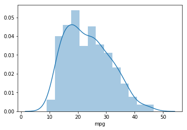

```python
sns.distplot(df['mpg'])
plt.show()
```

```python
print("Skewness: %f" % df['mpg'].skew())
print("Kurtosis: %f" % df['mpg'].kurt())
```

```
Skewness: 0.457066
Kurtosis: -0.510781
```

```python
from sklearn.cluster import KMeans
```

```python
kmeans=KMeans(n_clusters=3)
```

```python
df.columns
```

```
Index([u'mpg', u'cylinders', u'displacement', u'horsepower', u'weight',
       u'acceleration', u'model year', u'origin', u'car name'],
      dtype='object')
```

```python
kmeans.fit(df.drop(['cylinders','displacement','weight','acceleration','model year','origin','car name'],axis=1))
```

```
KMeans(algorithm='auto', copy_x=True, init='k-means++', max_iter=300,
    n_clusters=3, n_init=10, n_jobs=1, precompute_distances='auto',
    random_state=None, tol=0.0001, verbose=0)
```

```python
print(kmeans.cluster_centers_)
```

```
[[ 14.48222222 164.44444444]
 [ 31.20373134  69.8358209 ]
 [ 22.26494253  99.74137931]]
```

```python
y=kmeans.labels_
print(y)
```

```
[2 0 0 0 0 0 0 0 0 0 0 0 0 0 2 2 2 2 2 1 2 2 2 2 2 0 0 0 0 2 2 2 2 2 2 2 2
 2 0 0 0 0 0 0 0 2 1 2 2 2 2 1 1 1 1 1 1 2 1 1 2 2 0 0 0 0 0 0 0 0 0 2 0 2
 0 0 2 1 2 1 2 2 2 1 2 0 0 0 0 0 0 0 0 0 0 0 0 2 2 2 2 2 1 0 0 0 0 2 2 1 2
 2 2 2 2 0 0 1 1 2 2 0 2 2 0 2 2 2 2 1 1 1 1 2 2 2 0 0 0 0 0 1 1 1 1 1 1 1
 1 2 2 1 2 2 1 1 0 0 0 0 2 2 2 2 2 2 2 1 1 2 1 2 1 2 2 1 2 2 2 2 2 1 2 1 2
 1 1 0 0 2 0 2 2 1 2 1 1 1 1 2 1 2 2 1 1 1 1 2 0 2 2 2 0 0 2 0 1 1 1 2 1 0
 2 0 2 2 2 2 2 0 0 0 0 1 2 1 2 1 1 1 1 2 2 2 1 1 1 1 1 2 0 0 2 2 2 2 2 2 2
 2 2 2 0 0 0 0 1 2 2 1 2 2 2 2 2 2 2 0 1 1 2 2 2 2 2 2 2 0 0 0 0 2 0 1 1 1
 1 1 2 1 2 1 1 1 1 2 2 2 2 1 1 1 1 2 2 2 2 1 2 1 2 1 1 2 1 1 1 1 1 1 2 1 1
 2 2 2 2 1 1 1 2 2 1 1 1 1 1 1 1 1 1 1 1 1 2 1 1 2 1 1 1 2 2 2 2 2 2 2 2 2
 1 1 2 2 2 1 1 1 1 1 2 1 1 1 1 1 2 1 2 2 2 1 2 2 1 1 1 1]
```

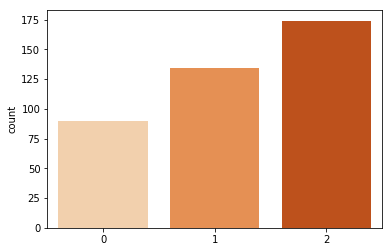

```python
sns.countplot(x=kmeans.labels_, palette='Oranges')
plt.show()
```

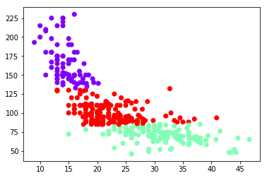

```python
plt.scatter(df.iloc[:,0].values,df.iloc[:,3].values, c=kmeans.labels_, cmap="rainbow")
plt.show()
```

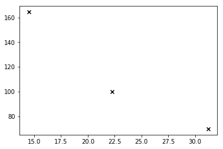

```python
centers = np.array(kmeans.cluster_centers_)
plt.scatter(centers[:,0], centers[:,1], marker="x", color='k')
```

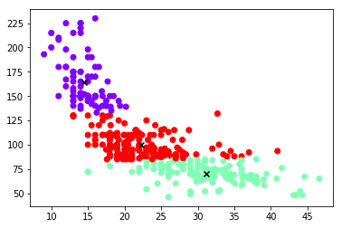

```python
plt.scatter(df.iloc[:,0].values,df.iloc[:,3].values, c=kmeans.labels_, cmap="rainbow")
centers = np.array(kmeans.cluster_centers_)
plt.scatter(centers[:,0], centers[:,1], marker="x", color='k')
plt.show()
```

## Determining The Optimal Number Of Clusters

- Determining the optimal number of clusters in a data set is a fundamental issue in partitioning clustering, such as k-means clustering, which requires the user to specify the number of clusters k to be generated.
- Unfortunately, there is no definitive answer to this question.
- The optimal number of clusters is somehow subjective and depends on the method used for measuring similarities and the parameters used for partitioning.
- A simple and popular solution consists of inspecting the dendrogram produced using hierarchical clustering to see if it suggests a particular number of clusters.
- Unfortunately, this approach is also subjective.

## Elbow method

- The basic idea behind partitioning methods, such as k-means clustering, is to define clusters such that the total intra-cluster variation [or total within-cluster sum of square (WSS)] is minimized.
- The total WSS measures the compactness of the clustering and we want it to be as small as possible.
- The Elbow method looks at the total WSS as a function of the number of clusters: One should choose a number of clusters so that adding another cluster doesn’t improve much better the total WSS.
1. Compute clustering algorithm (e.g., k-means clustering) for different values of k. For instance, by varying k from 1 to 10 clusters.
2. For each k, calculate the total within-cluster sum of square (wss).
3. Plot the curve of wss according to the number of clusters k.
4. The location of a bend (knee) in the plot is generally considered as an indicator of the appropriate number of clusters.

```python
from scipy.spatial.distance import cdist, pdist
from sklearn.cluster import KMeans
```

```python
K = range(1,10)
KM = [KMeans(n_clusters=k).fit(X) for k in K]
centroids = [k.cluster_centers_ for k in KM]
D_k = [cdist(X, cent, 'euclidean') for cent in centroids]
cIdx = [np.argmin(D,axis=1) for D in D_k]
dist = [np.min(D,axis=1) for D in D_k]
avgWithinSS = [sum(d)/X.shape[0] for d in dist]
```

```python
# Total with-in sum of square
wcss = [sum(d**2) for d in dist]
tss = sum(pdist(X)**2)/X.shape[0]
bss = tss-wcss
varExplained = bss/tss*100
```

```python
kIdx = 10-1
```

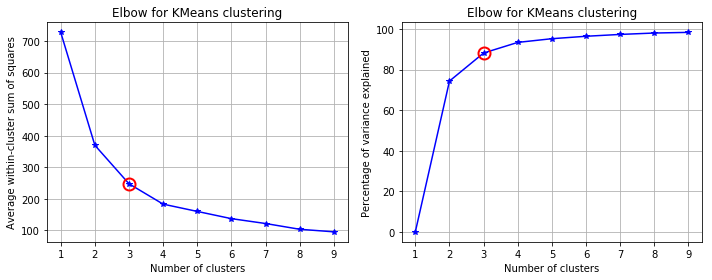

```python
##### plot ###
kIdx = 2
# elbow curve
# Set the size of the plot
plt.figure(figsize=(10,4))
plt.subplot(1, 2, 1)
plt.plot(K, avgWithinSS, 'b*-')
plt.plot(K[kIdx], avgWithinSS[kIdx], marker='o', markersize=12,
markeredgewidth=2, markeredgecolor='r', markerfacecolor='None')
plt.grid(True)
plt.xlabel('Number of clusters')
plt.ylabel('Average within-cluster sum of squares')
plt.title('Elbow for KMeans clustering')
plt.subplot(1, 2, 2)
plt.plot(K, varExplained, 'b*-')
plt.plot(K[kIdx], varExplained[kIdx], marker='o', markersize=12,
markeredgewidth=2, markeredgecolor='r', markerfacecolor='None')
plt.grid(True)
plt.xlabel('Number of clusters')
plt.ylabel('Percentage of variance explained')
plt.title('Elbow for KMeans clustering')
plt.tight_layout()
```

## Average silhouette method

#### The algorithm is similar to the elbow method and can be computed as follow:

1. Compute clustering algorithm (e.g., k-means clustering) for different values of k. For instance, by varying k from 1 to 10 clusters.
2. For each k, calculate the average silhouette of observations (avg.sil).
3. Plot the curve of avg.sil according to the number of clusters k.
4. The location of the maximum is considered as the appropriate number of clusters.

```python
from sklearn.metrics import silhouette_samples,silhouette_score
```

```python
silhouette_score(x,y)
```

```
0.58599334400624759
```

```python
from sklearn.metrics import silhouette_score
from matplotlib import cm
```

```python
score = []
for n_clusters in range(2,10):
    kmeans = KMeans(n_clusters=n_clusters)
    kmeans.fit(X)
    labels = kmeans.labels_
    centroids = kmeans.cluster_centers_
    score.append(silhouette_score(X, labels, metric='euclidean'))
```

```
Text(0.5,1,'Silouette for K-means')
```

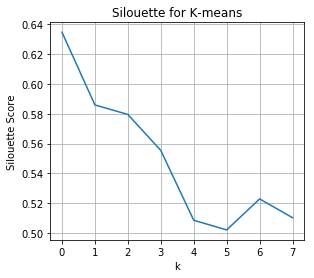

```python
# Set the size of the plot
plt.figure(figsize=(10,4))
plt.subplot(1, 2, 1)
plt.plot(score)
plt.grid(True)
plt.ylabel("Silouette Score")
plt.xlabel("k")
plt.title("Silouette for K-means")
```

## Pros and cons of clustering(K-Means):

## PROS :-

- Simple ,Understandable
- items automatically assigned to clusters

## CONS :-

- Must pick a no of clusters beforehand
- All items forced into a cluster
- to sensitive to noise,outlier points
- Different intial clusters result into different final clusters

# In class lab WAP

```
Data Set Name: 'auto-mpg.csv'
```

### Context

The data is technical spec of cars. The dataset is downloaded from UCI Machine Learning Repository

### Content

Title: Auto-Mpg Data

Sources: (a) Origin: This dataset was taken from the StatLib library which is maintained at Carnegie Mellon University. The dataset was used in the 1983 American Statistical Association Exposition. (c) Date: July 7, 1993

This dataset is a slightly modified version of the dataset provided in the StatLib library. In line with the use by Ross Quinlan (1993) in predicting the attribute "mpg", 8 of the original instances were removed because they had unknown values for the "mpg" attribute. The original dataset is available in the file "auto-mpg.data-original".

"The data concerns city-cycle fuel consumption in miles per gallon, to be predicted in terms of 3 multivalued discrete and 5 continuous attributes." (Quinlan, 1993)

Number of Instances: 398

Number of Attributes: 9 including the class attribute

### Attribute Information:

mpg: continuous cylinders: multi-valued discrete displacement: continuous horsepower: continuous weight: continuous acceleration: continuous model year: multi-valued discrete origin: multi-valued discrete car name: string (unique for each instance) Missing Attribute Values: horsepower has 6 missing values

1. Make Clusters and visualize the clusters using features such as mpg,acceleration .Also Evaluate them.
2. Make Clusters and visualize the clusters using features such as horsepower,weight .Also Evaluate them.
3. Make Clusters and visualize the clusters using features such as cylinders,horsepower .Also Evaluate them.
4. Make Clusters and visualize the clusters using 3 features such as cylinders,horsepower,displacement.Also Evaluate them.
5. For all the questions above find out the best value of K.

# Take home assignment***

Based on the previous dataset "wineQualityReds.csv", solve the below questions:

Apply Data Cleaning to the Datasets and then apply Kmeans algorithm for find pattern and the best value of.the K for the following features.

1. Use feautes fixed acidity and volatile acidity
2. Use feautes Cirtic acidity and fixed acidity
3. Use feautes residual suger and sulphades
4. Use feautes free.sulfur.dioxide and total.sulfur.dioxide
5. Use feautes fixed acidity, citric acidity and volatile acidity
6. Use feautes density and pH